# 2. Numpy 總複習2_Q slides

## Numpy 總複習2

### Da-Wei Chiang

## 大綱

- 常用基本函數(續)
  - `flatten`方法
  - `ravel`方法
  - `tile`方法
  - `newaxis`屬性
  - 其它常用基本函數
- 常用數學函數
- `Broadcasting`
- `Numpy`進階取值技巧

## 常用基本函數(續)

- `flatten`方法
- `ravel`方法
- `tile`方法
- `newaxis`屬性
- 其它常用基本函數

## `flatten`方法

```
ndarray_Variable.flatten()
```

```python
## 範例

import numpy as np

num = np.arange(1, 10).reshape(3, -1)
print(num)
num_flatten = num.flatten()
print(num_flatten)

num = np.arange(1, 9).reshape(2, 2, 2)
print(num)
num_flatten = num.flatten()
print(num_flatten)
```

```
[[1 2 3]
 [4 5 6]
 [7 8 9]]
[1 2 3 4 5 6 7 8 9]
[[[1 2]
  [3 4]]

 [[5 6]
  [7 8]]]
[1 2 3 4 5 6 7 8]
```

## 練習

- 請自行建構`ndarray`, 並練習使用`flatten`

```python
## 請猜猜以下執行結果

import numpy as np

num = np.arange(1, 7).reshape(2, 3)
print(num)
num.flatten()
print(num)
```

```python
## 請猜猜以下執行結果

import numpy as np

num = np.arange(1, 7).resize(2, -1)
print(num)
num = np.flatten(num)
print(num)
```

```python
## 請猜猜以下執行結果

import numpy as np

num = np.arange(1, 7).resize(2, 2)
print(num)
num1 = num.flatten()
num1[0] = 100
print(num1)
print(num)
```

## 上例為`flatten`重要特性，當擴展時會重新建構新物件

## `ravel`方法

```
np.ravel(ndarray_Variable)

ndarray_Variable.ravel()
```

```python
## 範例

import numpy as np

num = np.arange(1, 5).reshape(2, 2)
print(num)
num_ravel = num.ravel()
print(num_ravel)
print("- - - - -")
print(num)
np_ravel = np.ravel(num)
print(np_ravel)
```

```
[[1 2]
 [3 4]]
[1 2 3 4]
- - - - -
[[1 2]
 [3 4]]
[1 2 3 4]
```

## 練習

- 請自行建構`ndarray`, 並練習使用`ravel`

```python
## 請猜猜以下執行結果

import numpy as np

num = np.arange(1, 9).reshape(2, 2, 2)
print(num)

num_ravel = np.resize(num.ravel(), (2, 2))
print(num_ravel)
print("- - - -")
num_ravel[0][0] = 100
print(num)
```

```python
## 請猜猜以下執行結果

import numpy as np

num = np.resize(np.arange(1, 9), (2, 3))
print(num)
num_ravel = num.ravel()
num_ravel[0] = 100
print(num)
```

## 上例為`ravel`重要特性，`ravel`在擴展時會參照相同的記憶體位置

## `tile`方法

```
np.tile(ndarray, repeat)
```

```python
## 範例

import numpy as np

num = np.arange(5)
print(num)
onedim_num = np.tile(num, 2)
print(onedim_num)
```

```
[0 1 2 3 4]
[0 1 2 3 4 0 1 2 3 4]
```

## 練習

- 請自行建立`ndarray`, 並練習使用`tile`方法

```python
## 請猜猜以下執行結果

import numpy as np

num = np.arange(4)
print(num)
twodim_num = np.tile(num, (2, 2))
print(twodim_num)
print("- - - - - -")
num = num.reshape(2, 2)
print(num)
twodim_num = np.tile(num, (3, 2))
print(twodim_num)
print("- - - - - -")
num = np.arange(8)
num = num.reshape(2, 2, 2)
threedim_num = np.tile(num, (3, 2))
print(threedim_num)
```

## newaxis屬性

```
np.newaxis
```

```python
## 範例

import numpy as np

print(np.newaxis)
num = np.arange(5)
print(num)
num_newaxis_1 = num[np.newaxis, :]    #寫法一
print(num_newaxis_1)
print(num_newaxis_1.shape)
num_newaxis_2 = num[None, :]    #寫法二
print(num_newaxis_2)
print(num_newaxis_2.shape)
```

```
None
[0 1 2 3 4]
[[0 1 2 3 4]]
(1, 5)
[[0 1 2 3 4]]
(1, 5)
```

## 練習

- 請自行建立`ndarray`, 並練習使用`np.newaxis`方法

```python
## 請猜猜以下執行結果

import numpy as np

num = np.arange(10).reshape(2, 5)
num_1 = num[:, None, :]
print(num_1)
num_2 = num[:, None, 2]
print(num_2)
```

```python
## 請猜猜以下執行結果

import numpy as np

num = np.arange(10).reshape(2, 5)
print(num)
num_1 = num[:, :, None]
print(num_1)
num_1[0][0][0] = 1000
print(num)
```

## 我們可以透過`reshape`或`resize`來增加維度, 但不管使用哪一個都需要指定形狀的個數.

## `np.newaxis`可以再不指定個數的情況下直接增加維度

## 注意：`np.newaxis`的結果為`View`而非`Copy`

## 其它常用函數

- `np.zeros(shape)`:建構全部為`0`且形狀為`shape`的`ndarray`
- `np.ones(shape)`:建構全部為`1`且形狀為`shape`的`ndarray`
- `np.full(shape, value)`:建構全部為`value`且形狀為`shape`的`ndarray`
- `np.arange(start, end, step)`:建構由`start`開始、間隔`step`並且`end`結束的數列
- `np.linspace(start, end, num)`:建構由`start`開始、`end`結束，且均勻切割為`num`個資料點的數值陣列
- `np.random.random(size)`:建構介於 `0`與 `1` 之間、並符合均勻分佈的數值陣列
- `np.random.normal(loc, scale, size)`:建構平均數為`loc`、標準差為`scale`的標準差常態分佈的數值陣列
- `np.random.randint(low, high, size)`:建構指定從`low`到`high`之間隨機抽樣之正整數的數值陣列

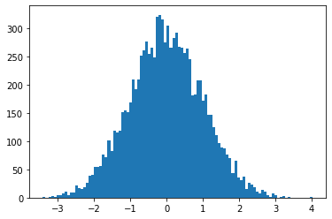

```python
## 範例 - random.normal
import numpy as np
import matplotlib.pyplot as plt

num = np.random.normal(0, 1, 10000)
n, bins, patches = plt.hist(num, 100)
plt.show()
```

```python
## 請猜猜以下執行結果

import numpy as np

num = np.arange(1, 10)
print(num)
num = np.arange(0.5, 5.5)
print(num)
num = np.arange(0.2, 0.8)
print(num)
num = np.arange(1, 2, 0.2)
print(num)
```

```python
## 請猜猜以下執行結果

import numpy as np

num = np.arange(3, dtype='float')
print(num)
num = np.arange(1, 5, dtype='int')
print(num)
num = np.arange(1, 5, dtype='float')
print(num)
num = np.arange(1, 2, 0.2, dtype='int')
print(num)
num = np.arange(0, 3, 0.5, dtype='int')
print(num)
```

[figure not shown]

## 常用數學函數

```
np.sum()
np.median()
np.mean()
np.dot()
ndarray_Variable.T
np.inner()
np.std()
np.var()
np.cov()
np.corrcoef()
```

```python
## 請猜猜以下執行結果

import numpy as np

num = np.arange(1, 9).reshape(2, 2, 2)
print(num)
print("- - - - -")
s1 = np.sum(num, axis=0)
print(s1)
print("- - - - -")
s2 = np.sum(num, axis=1)
print(s2)
print("- - - - -")
s2 = np.sum(num, axis=2)
print(s2)
```

```python
import numpy as np

num = np.random.randint(1, 100, 10).reshape(2, 5)
print(num)
## 請猜猜以下執行結果
m1 = np.max(num, axis=1)
print(m1)
m2 = np.min(num, axis=0)
print(m2)
```

```
[[47  2 72 27 19]
 [82 22 34 84 73]]
```

```python
## 請猜猜以下執行結果

import numpy as np

A = np.array([[1, 2], [3, 4]])
B = np.array([[5, 6], [7, 8]])
print("A", A, sep="\n")
print("B", B, sep="\n")
print("inner", np.inner(A, B), sep="\n")
print("dot", np.dot(A, B), sep="\n")
print("A Transpose", A.T, sep="\n")
```

```
A
[[1 2]
 [3 4]]
B
[[5 6]
 [7 8]]
inner
[[17 23]
 [39 53]]
dot
[[19 22]
 [43 50]]
A Transpose
[[1 3]
 [2 4]]
```

## `Broadcasting`

- `Numpy`與算術運算子結合的計算法則

```python
## 請猜猜以下執行結果

import numpy as np

num1 = np.arange(3)
num2 = np.arange(3).reshape(3,1)
print(num1+num2)
```

```python
import numpy as np

num1 = np.arange(16).reshape(4,4)
num2 = np.arange(4).reshape(2,2)

print(num1)
print(num2)
## 請猜猜以下執行結果
print(num1+num2)
```

```
[[ 0  1  2  3]
 [ 4  5  6  7]
 [ 8  9 10 11]
 [12 13 14 15]]
[[0 1]
 [2 3]]
```

## Broadcasting 規則整理

- `Broadcasting Rule`
  - 當兩個不同維度的`ndarray`要進行運算時，低維度的`ndarray`會墊充原本的元素
  - 當兩個`ndarray`的任何維度都不相等時，會拉長形狀是1的`ndarray`，使兩個`ndarray`形狀相同
  - 當兩個`ndarray`的任何維度都不相等時，且沒有形狀為1時，則產生錯誤

## `Numpy`進階取值技巧

- `Boolean Mask`
- `Fancy index`

## `Boolean Mask`

- `ndarray`透過`bool`取值

```python
## 範例

import numpy as np

num = np.arange(1, 20, 2)
print("原始數列 = ", num)
bigger_five = num>5
print("大於5布林值 = ", bigger_five)
print("結合上述兩者，篩遠大於5的數",num[bigger_five])

print("- - - - - - - - -")
print("篩遠大於5的數可縮寫為", num[num>5])
```

```
原始數列 =  [ 1  3  5  7  9 11 13 15 17 19]
大於5布林值 =  [False False False  True  True  True  True  True  True  True]
結合上述兩者，篩遠大於5的數 [ 7  9 11 13 15 17 19]
- - - - - - - - -
篩遠大於5的數可縮寫為 [ 7  9 11 13 15 17 19]
```

## 練習

- 隨機產生一個`20`個數的`ndarray`（介於`1~20`之間）
- 使用`Boolean Mask`篩選出所有偶數的數

## `Fancy Index`

- 取值的方式：以`list`的方式傳遞索引值

```python
## 範例

import numpy as np

num = np.random.randint(1, 20, 10)
print("num = ", num)
print("取索引值1, 5, 6的值", num[1], num[5], num[6])
print("- - - - - - - - -")
print("使用Fancy index")
index = [1, 5, 6]
print(num[index])
```

```
num =  [18 11  1 12 13  5 18  1 12 19]
取索引值1, 5, 6的值 11 5 18
- - - - - - - - -
使用Fancy index
[11  5 18]
```

```python
import numpy as np
num = np.arange(0, 25).reshape(5,5)
print(num)

## 請猜猜以下執行結果
col = [1]
row = [0, 2, 3]
print(num[row, col])
print(num[row][col])
```

```
[[ 0  1  2  3  4]
 [ 5  6  7  8  9]
 [10 11 12 13 14]
 [15 16 17 18 19]
 [20 21 22 23 24]]
```

## 練習

- 請自行建構`ndarray`並練習`Fancy Index`